# ANOVA_part_1_lab_script_answers

Andrew Stewart

15/11/2018

First we need to load the packages we’ll be using - these are the tidyverse, afex (for factorial ANOVA), emmeans (for running pairwise comparisons), and psych (for generating descriptive statistics.)

```r
library(tidyverse)
library(afex)
library(emmeans)
library(psych)
```

## Question 1

Now you need to load our first data file. This is called ANOVA_lab1_data1.csv - when you load it, you need to assign it to a new variable called ‘data’. Load it using the ‘Import Dataset’ button in the Environment window of RStudio.

```r
data <- read_csv("ANOVA_lab1_data1.csv")
```

24 participants responded to a word that was either common (i.e., high lexical frequency) or rare (i.e., low lexical frequency). This is our IV and is coded as ‘High’ vs. ‘Low’. Our DV is reaction time and is coded as ‘RT’. Subject number is coded as ‘Subject’. We want to know whether there is a difference between conditions (and if so, where that difference lies). Visualise the data, generate descrtiptives, and run the appropriate ANOVA to determine whether our independent variable (Condition) has an influence on our dependent variable (RT).

If you type ‘data’ you will see the first 10 rows of our dataframe..

```r
data
```

```
## # A tibble: 24 x 3
##    Subject Condition    RT
##      <int> <chr>     <int>
##  1       1 low        1103
##  2       2 low        1170
##  3       3 low        1225
##  4       4 low        1084
##  5       5 low        1219
##  6       6 low        1203
##  7       7 low        1208
##  8       8 low        1311
##  9       9 low        1078
## 10      10 low        1326
## # ... with 14 more rows
```

We need to set our Condition column to a factor.

```r
data$Condition <- as.factor(data$Condition)
```

We are first going to plot the data using ggplot - we’ll used both geom_violin() and geom_jitter() layers - this way we’ll be able to see both the distribution shapes, and also the raw data (but jittered so we don’t have lots of points basically on top of each other). We’re also going to add some summary statistics using the stat_summary function - specifically we’re asking for each condition mean plus the 95% confidence interval around each condition mean to be plotted.

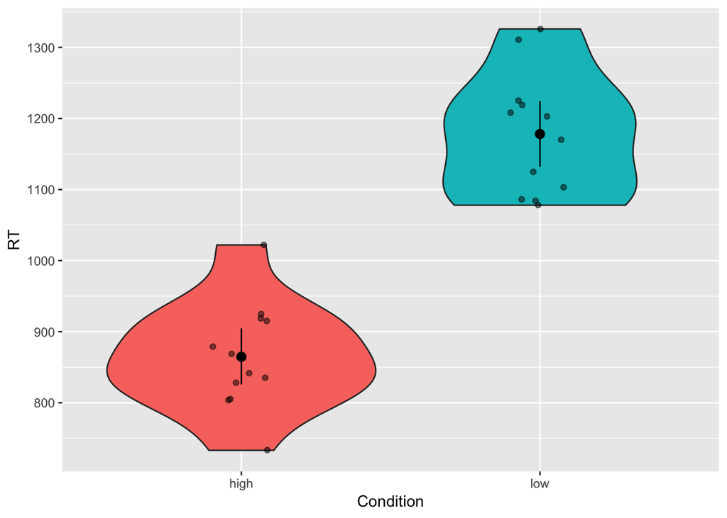

```r
ggplot(data, aes(x=Condition, y=RT, fill=Condition)) + geom_violin() +
  geom_jitter(width=.1, alpha=.5) + stat_summary(fun.data="mean_cl_boot") + guides(fill=FALSE)
```

We’re now going to generate some descriptives. First we will generate them using the describeBy() function in the psych package, and they we’re going to do it tidyverse-style.

```r
describeBy(data$RT, group=data$Condition)
```

```
##
##  Descriptive statistics by group
## group: high
##    vars  n   mean    sd median trimmed   mad min  max range skew kurtosis
## X1    1 12 864.67 74.72  855.5   862.1 75.61 733 1022   289 0.32    -0.41
##       se
## X1 21.57
## --------------------------------------------------------
## group: low
##    vars  n    mean    sd median trimmed    mad  min  max range skew
## X1    1 12 1178.17 85.71 1186.5  1173.4 107.49 1078 1326   248 0.34
##    kurtosis    se
## X1    -1.32 24.74
```

Note, we are using the pipe operator %>% which allows us to ‘pipe’ values from left to right. The following could be read as ‘take the dataframe called data, pass it along to the funciton group_by() and group our data by condition, pass this grouped data along to the summarise function and give me the mean and SD of the RT values for each group’.

```r
data %>% group_by(Condition) %>% summarise(mean(RT), sd(RT))
```

```
## # A tibble: 2 x 3
##   Condition `mean(RT)` `sd(RT)`
##   <fct>          <dbl>    <dbl>
## 1 high            865.     74.7
## 2 low            1178.     85.7
```

We’re now going to build our ANOVA model. This is a simple between subjects design do we can use the inbuilt aov() function. We are going to map the output to a variable we’re calling ‘model’.

```r
model <- aov(RT ~ Condition, data)
```

We can now ask for a summary of our model in ANOVA table format using the anova() function.

```r
anova(model)
```

```
## Analysis of Variance Table
##
## Response: RT
##           Df Sum Sq Mean Sq F value    Pr(>F)
## Condition  1 589694  589694  91.217 2.767e-09 ***
## Residuals 22 142224    6465
## ---
## Signif. codes:  0 '***' 0.001 '**' 0.01 '*' 0.05 '.' 0.1 ' ' 1
```

To interpret our output, we don’t need any further comparisons. Can you think why this is?

## Question 2

Our second datafile is called ANOVA_lab1_data2.csv. Load it and map it onto a variable called ‘data’.

```r
data <- read_csv("ANOVA_lab1_data2.csv")
```

These data are also from a rection time experiment but with a slightly more complex design. 48 participants responded to a word that differed in how frequent it was. This factor is between participants and we have four levels coded as ‘very low’, ‘low’, ‘high’, and ‘very high’. Our DV is reaction time and is coded as ‘RT’. Subject number is coded as ‘Subject’. We want to tell if there is a difference between our conditions (and if so, where that difference lies).

We need to set our Condition column to a factor.

```r
data$Condition <- as.factor(data$Condition)
```

Let’s plot the data…

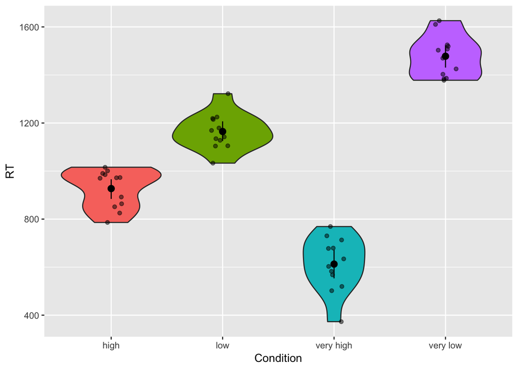

```r
ggplot(data, aes(x=Condition, y=RT, fill=Condition)) + geom_violin() +
  geom_jitter(width=.1, alpha=.5) + stat_summary(fun.data="mean_cl_boot") + guides(fill=FALSE)
```

Note that it might be better to swap around the order of the factors in our plot. We can do that using the factor() function. Let’s reorder…

```r
data$Condition <- factor(data$Condition, levels=c("very low", "low", "high", "very high"))
```

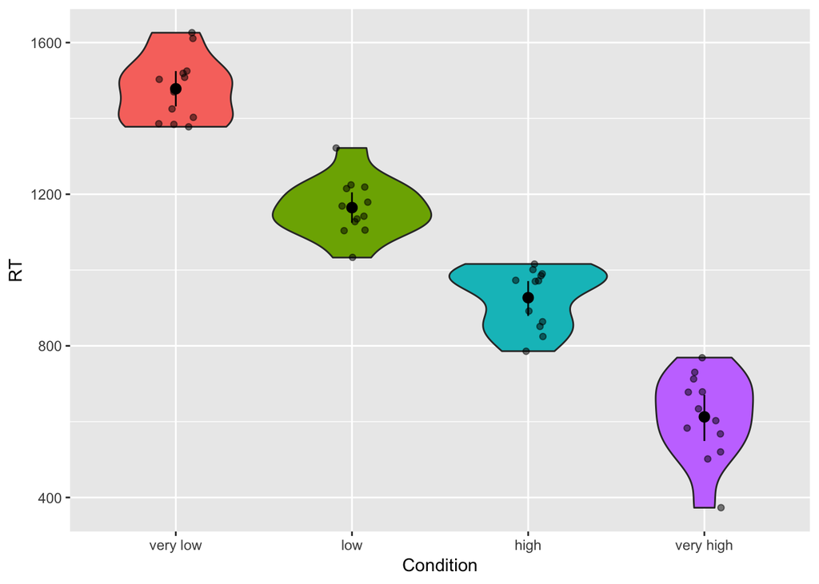

```r
ggplot(data, aes(x=Condition, y=RT, fill=Condition)) + geom_violin() +
  geom_jitter(width=.1, alpha=.5) + stat_summary(fun.data="mean_cl_boot") + guides(fill=FALSE)
```

This graph looks better.

Now let’s generate some descriptives using describeBy and using tidyverse.

```r
describeBy(data$RT, group=data$Condition)
```

```
##
##  Descriptive statistics by group
## group: very low
##    vars  n    mean    sd median trimmed    mad  min  max range skew
## X1    1 12 1478.17 85.71 1486.5  1473.4 107.49 1378 1626   248 0.34
##    kurtosis    se
## X1    -1.32 24.74
## --------------------------------------------------------
## group: low
##    vars  n    mean    sd median trimmed   mad  min  max range skew
## X1    1 12 1164.67 74.72 1155.5  1162.1 75.61 1033 1322   289 0.32
##    kurtosis    se
## X1    -0.41 21.57
## --------------------------------------------------------
## group: high
##    vars  n   mean    sd median trimmed  mad min  max range  skew kurtosis
## X1    1 12 927.08 78.61    971   932.3 55.6 786 1016   230 -0.48     -1.5
##       se
## X1 22.69
## --------------------------------------------------------
## group: very high
##    vars  n   mean     sd median trimmed   mad min max range  skew kurtosis
## X1    1 12 612.67 112.27  618.5     621 114.9 373 769   396 -0.53    -0.66
##       se
## X1 32.41
```

```r
data %>% group_by(Condition) %>% summarise (mean(RT), sd(RT))
```

```
## # A tibble: 4 x 3
##   Condition `mean(RT)` `sd(RT)`
##   <fct>          <dbl>    <dbl>
## 1 very low       1478.     85.7
## 2 low            1165.     74.7
## 3 high            927.     78.6
## 4 very high       613.    112.
```

Finally, let’s build our model. Again it is a between subjects design with one factor so we can just use the inbuilt aov() function.

```r
model <- aov(RT ~ Condition, data)
anova(model)
```

```
## Analysis of Variance Table
##
## Response: RT
##           Df  Sum Sq Mean Sq F value    Pr(>F)
## Condition  3 4833219 1611073  203.21 < 2.2e-16 ***
## Residuals 44  348840    7928
## ---
## Signif. codes:  0 '***' 0.001 '**' 0.01 '*' 0.05 '.' 0.1 ' ' 1
```

Let’s interpret the main effect using the emmeans() function and correcting for multiple comparisons using the Bonferroni correction.

```r
emmeans(model, pairwise ~ Condition, adjust="Bonferroni")
```

```
## $emmeans
##  Condition    emmean       SE df  lower.CL  upper.CL
##  very low  1478.1667 25.70373 44 1426.3642 1529.9691
##  low       1164.6667 25.70373 44 1112.8642 1216.4691
##  high       927.0833 25.70373 44  875.2809  978.8858
##  very high  612.6667 25.70373 44  560.8642  664.4691
##
## Confidence level used: 0.95
##
## $contrasts
##  contrast             estimate       SE df t.ratio p.value
##  very low - low       313.5000 36.35056 44   8.624  <.0001
##  very low - high      551.0833 36.35056 44  15.160  <.0001
##  very low - very high 865.5000 36.35056 44  23.810  <.0001
##  low - high           237.5833 36.35056 44   6.536  <.0001
##  low - very high      552.0000 36.35056 44  15.185  <.0001
##  high - very high     314.4167 36.35056 44   8.650  <.0001
##
## P value adjustment: bonferroni method for 6 tests
```

## Question 3

Open the datafile ANOVA_lab1_data3.csv and map it onto the variable ‘data’.

```r
data <- read_csv("ANOVA_lab1_data3.csv")
```

These data are from a 2 x 2 repeated measures reaction time experiment. We were interested in how quickly participants could respond to images that were Large vs. Small and in Colour vs. B & W. We expect that Large Colour images will be responded to more quickly than Small B & W images. We’re not sure about Small Colour images and Large B & W images. We measured the response times of 24 participants responding to an image in each of these four conditions. We want to tell if there is a difference between our conditions (and if so, where that difference lies).

We need to set the two columns (Size and Colour) as factors.

```r
data$Size <- as.factor(data$Size)
data$Colour <- as.factor(data$Colour)
```

First let’s plot (and roll)…

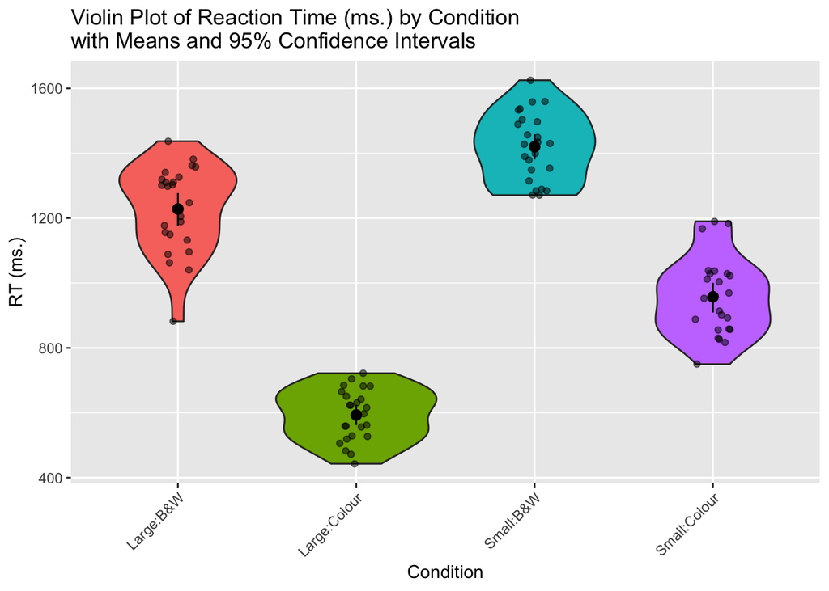

```r
ggplot(data, aes(x=Size:Colour, y=RT, fill=Size:Colour)) + geom_violin() +
  geom_jitter(width=.1, alpha=.5) + stat_summary(fun.data="mean_cl_boot", colour="black") +
  guides(fill=FALSE) + labs(x="Condition", y="RT (ms.)", title="Violin Plot of Reaction Time (ms.) by Condition\nwith Means and 95% Confidence Intervals") +
  theme(axis.text.x = element_text(angle = 45, hjust = 1))
```

Now we’re going to generate some descriptives.

```r
describeBy(data$RT, group=list(data$Size, data$Colour))
```

```
##
##  Descriptive statistics by group
## : Large
## : B&W
##    vars  n    mean     sd median trimmed    mad min  max range  skew
## X1    1 24 1228.04 133.11   1273  1236.6 128.99 882 1437   555 -0.65
##    kurtosis    se
## X1    -0.24 27.17
## --------------------------------------------------------
## : Small
## : B&W
##    vars  n    mean     sd median trimmed   mad  min  max range skew
## X1    1 24 1420.17 104.05   1429  1417.9 114.9 1271 1625   354 0.09
##    kurtosis    se
## X1    -1.19 21.24
## --------------------------------------------------------
## : Large
## : Colour
##    vars  n   mean    sd median trimmed   mad min max range  skew kurtosis
## X1    1 24 593.33 79.03  606.5   594.9 99.33 443 722   279 -0.16    -1.21
##       se
## X1 16.13
## --------------------------------------------------------
## : Small
## : Colour
##    vars  n   mean     sd median trimmed    mad min  max range skew
## X1    1 24 957.42 118.33  954.5   951.9 116.38 750 1190   440 0.39
##    kurtosis    se
## X1    -0.71 24.15
```

```r
data %>% group_by(Size, Colour) %>% summarise(mean(RT), sd(RT))
```

```
## # A tibble: 4 x 4
## # Groups:   Size [?]
##   Size  Colour `mean(RT)` `sd(RT)`
##   <fct> <fct>       <dbl>    <dbl>
## 1 Large B&W         1228.    133.
## 2 Large Colour       593.     79.0
## 3 Small B&W         1420.    104.
## 4 Small Colour       957.    118.
```

As it is a factorial design we will build our ANOVA model using the aov_4() function in the afex package. The term (1+Size*Colour|Subject) corresponds to our two repeated measures factors and the fact we’re aggregating over our Subjects (this will make more sense when we move onto mixed models using the lme4 package next semester…)

```r
model <- aov_4(RT ~ Size*Colour + (1+Size*Colour|Subject), data)
summary(model)
```

```
##
## Univariate Type III Repeated-Measures ANOVA Assuming Sphericity
##
##                Sum Sq num Df Error SS den Df  F value    Pr(>F)
## (Intercept) 105787507      1   222362     23 10942.11 < 2.2e-16 ***
## Size          1856206      1   214572     23   198.97 8.235e-13 ***
## Colour        7226489      1   317030     23   524.27 < 2.2e-16 ***
## Size:Colour    177418      1   368287     23    11.08  0.002921 **
## ---
## Signif. codes:  0 '***' 0.001 '**' 0.01 '*' 0.05 '.' 0.1 ' ' 1
```

Our interaction is significant so we run pairwise comparisons to determine where our difference(s) is/are…

```r
emmeans(model, pairwise ~ Size*Colour, adjust="Bonferroni")
```

```
## $emmeans
##  Size  Colour    emmean       SE    df  lower.CL upper.CL
##  Large B.W    1228.0417 22.54476 87.35 1183.2340 1272.849
##  Small B.W    1420.1667 22.54476 87.35 1375.3590 1464.974
##  Large Colour  593.3333 22.54476 87.35  548.5257  638.141
##  Small Colour  957.4167 22.54476 87.35  912.6090 1002.224
##
## Confidence level used: 0.95
##
## $contrasts
##  contrast                     estimate       SE    df t.ratio p.value
##  Large,B.W - Small,B.W       -192.1250 32.49468 43.01  -5.913  <.0001
##  Large,B.W - Large,Colour     634.7083 35.23515 45.74  18.013  <.0001
##  Large,B.W - Small,Colour     270.6250 31.03301 44.35   8.721  <.0001
##  Small,B.W - Large,Colour     826.8333 31.03301 44.35  26.644  <.0001
##  Small,B.W - Small,Colour     462.7500 35.23515 45.74  13.133  <.0001
##  Large,Colour - Small,Colour -364.0833 32.49468 43.01 -11.204  <.0001
##
## P value adjustment: bonferroni method for 6 tests
```

Even with the conservative Bonferroni adjustment, you’ll see that every condition differs from every other condition.